# Weight lifting exercise analysis

Marina Peremyslova

November 17, 2015

## Summary

Using devices such as Jawbone Up, Nike FuelBand, and Fitbit it is now possible to collect a large amount of data about personal activity relatively inexpensively. These type of devices are part of the quantified self movement – a group of enthusiasts who take measurements about themselves regularly to improve their health, to find patterns in their behavior, or because they are tech geeks. One thing that people regularly do is quantify how much of a particular activity they do, but they rarely quantify how well they do it. In this project, the goal will be to use data from accelerometers on the belt, forearm, arm, and dumbell of 6 participants. They were asked to perform barbell lifts correctly and incorrectly in 5 different ways. More information is available from the website [here](http://groupware.les.inf.puc-rio.br/har) (see the section on the Weight Lifting Exercise Dataset).

## Data preparation

### Examining the data

The data analyzed is taken from this [source](http://groupware.les.inf.puc-rio.br/har). This dataset is licensed under the Creative Commons license (CC BY-SA). Let’s load the data and see how it looks:

```r
#importing the data from the web
trainfileURL<-"https://d396qusza40orc.cloudfront.net/predmachlearn/pml-training.csv"
testfileURL<-"https://d396qusza40orc.cloudfront.net/predmachlearn/pml-testing.csv"

download.file(trainfileURL,destfile="train.csv",method="curl")
train_df_null<-read.csv("train.csv")

download.file(testfileURL,destfile="test.csv",method="curl")
test_df_null<-read.csv("test.csv")

#checking the features
names(train_df_null)
```

```
##   [1] "X"                        "user_name"
##   [3] "raw_timestamp_part_1"     "raw_timestamp_part_2"
##   [5] "cvtd_timestamp"           "new_window"
##   [7] "num_window"               "roll_belt"
##   [9] "pitch_belt"               "yaw_belt"
##  [11] "total_accel_belt"         "kurtosis_roll_belt"
##  [13] "kurtosis_picth_belt"      "kurtosis_yaw_belt"
##  [15] "skewness_roll_belt"       "skewness_roll_belt.1"
##  [17] "skewness_yaw_belt"        "max_roll_belt"
##  [19] "max_picth_belt"           "max_yaw_belt"
##  [21] "min_roll_belt"            "min_pitch_belt"
##  [23] "min_yaw_belt"             "amplitude_roll_belt"
##  [25] "amplitude_pitch_belt"     "amplitude_yaw_belt"
##  [27] "var_total_accel_belt"     "avg_roll_belt"
##  [29] "stddev_roll_belt"         "var_roll_belt"
```

[output cut: 65 more lines]

The goal of this project is to predict the manner in which exercises were done. This is the “classe” variable in the training set. Six young health participants were asked to perform one set of 10 repetitions of the Unilateral Dumbbell Biceps Curl in five different fashions: exactly according to the specification (Class A), throwing the elbows to the front (Class B), lifting the dumbbell only halfway (Class C), lowering the dumbbell only halfway (Class D) and throwing the hips to the front (Class E).

Class A corresponds to the specified execution of the exercise, while the other 4 classes correspond to common mistakes.

### Cleaning the data

If we look at the actual data by using summary(train_df_null) operation, we’ll see that some of the features have lots of missing values, so we will need to choose missing values imputation strategy in order to proceed forward. We can also notice a certain pattern in missing data: there are exactly *19216* missing values for the features with missing data. Given that we have 19622 samples in the train set, 19216 makes almost 98% percent of all samples, so we’re going to filter out all variables that have more than 80% of missing values. We will then take out the same variables from the test dataset.

```r
#creating index of all columns that don't have NAs more than 80%
na_ind<-apply(!is.na(train_df_null),2,sum)>0.8*nrow(train_df_null)
#subsetting train and test sets with the same index vector
train_df_prep1<-train_df_null[,na_ind]
test_df_prep1<-test_df_null[,na_ind]
```

If we now run summary(train_df_prep1), we’ll see that the data now looks much better. Now we’re going to check how varible our features are and filter the ones with near zero variance:

```r
library(caret)
#creating index of all predictors that have near zero variance:
nzv_ind_df<-nearZeroVar(train_df_prep1, saveMetrics=TRUE)
#subsetting train and test sets with the same index vector
train_df_prep2<-train_df_prep1[,nzv_ind_df$nzv==FALSE]
test_df_prep2<-test_df_prep1[,nzv_ind_df$nzv==FALSE]
```

We will also clean variables such as X, user_name, raw_timestamp_part1,raw_timestamp_part2,cvtd_timestamp and num_window as we consider them irrelevant to the outcome:

```r
train_df_prep3<-train_df_prep2[,-c(1:6)]
test_df_prep3<-test_df_prep2[,-c(1:6)]
```

And we’re quickly making sure that there are no NAs left in the data:

```r
sum(is.na(train_df_prep3))
```

```
## [1] 0
```

```r
sum(is.na(test_df_prep3))
```

```
## [1] 0
```

After all these procedures we will end up with the following number of columns:

```r
ncol(train_df_prep3)
```

```
## [1] 53
```

### Data normalization

Using the same summary() operation again, we could also see that the value scale varies greatly by feature, which can potentially have negative impact on our model training and testing. So we need to normalize the data. We’re going to use $x-min(x)/max(x)-min(x)$ formulae for data normalization in order to receive the values between 0 and 1:

```r
#creating two-row dataframe with min and max values for each variable taken from the dataset
min_row_train<-unlist((lapply(train_df_prep3[,-53], FUN=min)))
max_row_train<-unlist((lapply(train_df_prep3[,-53], FUN=max)))


k<-nrow(train_df_prep3)
l<-ncol(train_df_prep3)-1
train_df_matrix<-matrix(0,nrow=k,ncol=l)
for(i in 1:k){
   for(j in 1:l){
train_df_matrix[i,j]<-(train_df_prep3[i,j]-min_row_train[j])/(max_row_train[j]-min_row_train[j])
}
}
#converting the matrix into the data.frame
train_df<-cbind(as.data.frame(train_df_matrix),train_df_prep3$classe)
colnames(train_df)<-colnames(train_df_prep3)
```

We will repeat the same data normalization procedure for our test set, however, we’ll be using min and max values taken from the train set:

```r
k<-nrow(test_df_prep3)
l<-ncol(test_df_prep3)-1

#creating two-row dataframe with min and max values for each variable taken from the dataset
test_df_matrix<-matrix(0,nrow=k,ncol=l)
for(i in 1:k){
   for(j in 1:l){
test_df_matrix[i,j]<-(test_df_prep3[i,j]-min_row_train[j])/(max_row_train[j]-min_row_train[j])
}
}
#converting the matrix into the data.frame
#note that the last column of the data set is called problem_id, which we will use for testing in order to compare our predictions on the test dataset with the target ones
test_df<-cbind(as.data.frame(test_df_matrix),test_df_prep3$problem_id)
colnames(test_df)<-colnames(test_df_prep3)
```

## Model training

In order to better predict the error we’ll receive on the test set after training the model on the training set, we’re going to split the training set into two sets:

1. training set (we’ll use 60% of our training data for this purpose)
2. validation set (40% of the training data)

Such data partition will help us to do cross-validation and better predict the out-of-sample error since we’ll likely face model overfitting, which would have resulted in more optimistic accuracy prediction than in the reality (i.e. when using the model outisde of the training sample).

```r
inTrain <- createDataPartition(train_df$classe, p=0.60, list=FALSE)
train_df <- train_df[inTrain, ]
#creating validation dataset of what's not in the training set
validation_df <- train_df[-inTrain, ]
```

### Principal component analysis

Given the large number of potential predictors (*52*), we might want to reduce their numbers by combining them while keeping the information. We will use principal component analysis for this purpose:

```r
# create preprocess object
preProc <- preProcess(test_df[,-53], method="pca")
# calculate PCs for training data
trainPC <- predict(preProc,train_df[,-53])
# calculate PCs for validation data
validPC <- predict(preProc,validation_df[,-53])
# calculate PCs for test data
testPC <- predict(preProc,test_df[,-53])

#PCA results
preProc
```

```
## Created from 20 samples and 52 variables
##
## Pre-processing:
##   - centered (52)
##   - ignored (0)
##   - principal component signal extraction (52)
##   - scaled (52)
##
## PCA needed 12 components to capture 95 percent of the variance
```

### Cross-validation

After we preformed the PCA, we can now build the actual model and see how well it fits our data. We will use principal components to train *random forest* model on our training set:

```r
# run model on outcome and principle components
set.seed(2416)
modelFit <- train(train_df$classe ~ .,method="rf",data=trainPC)
modelFit
```

```
## Random Forest
##
## 11776 samples
##    11 predictor
##     5 classes: 'A', 'B', 'C', 'D', 'E'
##
## No pre-processing
## Resampling: Bootstrapped (25 reps)
## Summary of sample sizes: 11776, 11776, 11776, 11776, 11776, 11776, ...
## Resampling results across tuning parameters:
##
##   mtry  Accuracy   Kappa      Accuracy SD  Kappa SD
##    2    0.9338856  0.9163690  0.004255580  0.005371447
##    7    0.9248703  0.9049642  0.005325873  0.006738512
##   12    0.9039991  0.8785576  0.006613364  0.008401570
##
## Accuracy was used to select the optimal model using  the largest value.
## The final value used for the model was mtry = 2.
```

```r
# printing the final model along with its confusion matrix
modelFit$finalModel
```

```
##
## Call:
##  randomForest(x = x, y = y, mtry = param$mtry)
##                Type of random forest: classification
##                      Number of trees: 500
## No. of variables tried at each split: 2
##
##         OOB estimate of  error rate: 4.59%
## Confusion matrix:
##      A    B    C    D    E class.error
## A 3258   30   32   24    4  0.02688172
## B   66 2164   41    3    5  0.05046073
## C   19   46 1948   36    5  0.05160662
## D   10   11  106 1790   13  0.07253886
## E    8   28   31   22 2076  0.04110855
```

If we run our model on the validation set, we then receive even better results:

```r
valid_predict<-predict(modelFit,validPC)
pca_conf_matrix<-confusionMatrix(validation_df$classe,valid_predict)
pca_conf_matrix
```

```
## Confusion Matrix and Statistics
##
##           Reference
## Prediction    A    B    C    D    E
##          A 1353    0    0    0    0
##          B    0  894    0    0    0
##          C    0    0  837    0    0
##          D    0    0    0  775    0
##          E    0    0    0    0  859
##
## Overall Statistics
##
##                Accuracy : 1
##                  95% CI : (0.9992, 1)
##     No Information Rate : 0.2868
##     P-Value [Acc > NIR] : < 2.2e-16
##
##                   Kappa : 1
##  Mcnemar's Test P-Value : NA
##
## Statistics by Class:
##
##                      Class: A Class: B Class: C Class: D Class: E
## Sensitivity            1.0000   1.0000   1.0000   1.0000   1.0000
## Specificity            1.0000   1.0000   1.0000   1.0000   1.0000
## Pos Pred Value         1.0000   1.0000   1.0000   1.0000   1.0000
## Neg Pred Value         1.0000   1.0000   1.0000   1.0000   1.0000
## Prevalence             0.2868   0.1895   0.1774   0.1643   0.1821
## Detection Rate         0.2868   0.1895   0.1774   0.1643   0.1821
## Detection Prevalence   0.2868   0.1895   0.1774   0.1643   0.1821
## Balanced Accuracy      1.0000   1.0000   1.0000   1.0000   1.0000
```

Illustrating the dependancy between the number of randomly selected predictors and accuracy:

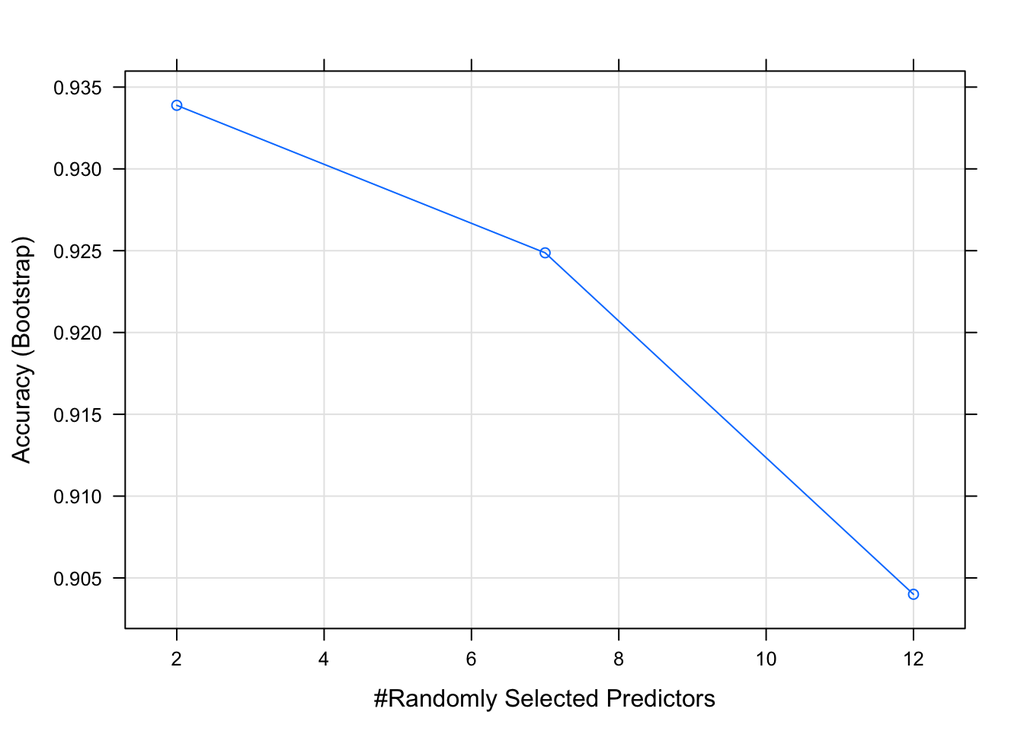

```r
#drawing the plot
plot(modelFit)
```

One of the PCA downsides is the lack of interpretability, so we aren’t going to visualize the result decision tree. Next time we’re going to try using another model to see how does it compare with PCA+RF approach.

## Running prebuilt test cases

Finally, we will preform the testing of our model on the test set. The trick with this test set was that we didn’t know the correct values so we could compare the outcomes only after the test results submission. Test results were prepared in a form .txt files with predicted classe letter in each. We preformerd the total of 20 test cases.

```r
answers<-predict(modelFit,testPC)

pml_write_files = function(x){
    n = length(x)
    for(i in 1:n){
        filename = paste0("problem_id_",i,".txt")
        write.table(x[i],file=filename,quote=FALSE,row.names=FALSE,col.names=FALSE)
    }
}
pml_write_files(answers)
#outputting the predict results for the illustration purposes:
predict(modelFit,testPC)
```

```
##  [1] B A A A A E D B A A B C B A E E A B B B
## Levels: A B C D E
```